# Determining the Relationship Between Mental Health Books and Suicide Rates

## Introduction

My motivation for this project was to find a topic that was of interest to me while also ensuring it was useful to society, in some way. I love movies and books and since we already looked at IMDB I decided to look at books. Now that I had a broad topic, I wanted to determine how this could be used to improve our world. After discovering the Open library API and looking into their data I determined I could I take data like publication years and a specific topic and use various libraries in python to analyze and visualize. I decided to look at identifying trends over time for books on mental health. Specifically, how the number of books published on this topic has changed over the years. I believe this is useful because libraries can curate collections based on what’s useful. This got me thinking about why something would be useful and how we can use cultral and social hisotry context. To better analyze the cultural context I want to combine this dataset with a dataset that looks at suicide rates over time to determine why/if these books were useful by reducing suicide rates. This can help us better understand what we can do to improve mental health in the United States.

## Data and Supporting Visualization

For the first part I focused on finding books on mental health before merging. I will be using the data source "Open Library API" to find data about mental health books, focusing on the publication year. I chose this because it was a pretty straightforward API database. I want to extract the key variable: subject and first_publish_year to make it easy to understand and visualize. I chose subject as mental health to help narrow down the results and to be able to analyze a connection between the mental health state of the world and the number of those books published in that time.

Search API was used because it has the most useful info like subject or publish_year as opposed to the others like developer API. The URL format for API for open library was simple. According to their website we need to take the search URL and add .json to the end.

```python
from requests import get # "get" requests can retrieve data from a server

# data manipulation
import pandas as pd
import numpy as np
# Base URL for Open Library API
url = "https://openlibrary.org/search.json"

# Response from the URL
# get is a function from requests

r= get(url)

r.url
```

```
'https://openlibrary.org/search.json'
```

```python
r.status_code  # Check the status code
```

```
200
```

```python
# add parameters
params = {
    "q": "title: mental health",      # titles related to mental health
    "language": "eng",                # only english books
    "limit": 1000,                    # Maximum results per request
    "fields": "title, publish_year",  # Include only these fields in the response
    "page": 1                         # starts at page 1
}


r = get(base_url, params=params)

# check status code
r.status_code
```

```
200
```

```python
print(r.content)
```

```python
json_result = r.json()
```

```python
type(json_result) # what kind of data is this?
```

```
dict
```

```python
json_result # able to view what was in the data like title, publish_year and subject
```

```python
json_result.keys()  # View JSON keys and we want to look at 'docs'
```

```
dict_keys(['numFound', 'start', 'numFoundExact', 'docs', 'num_found', 'q', 'offset'])
```

```python
type(json_result["docs"]) # what kind of data is this?
```

```
list
```

```python
# print results of all the books with only the title and publication year related to mental health
json_result['docs']
```

```python
books = json_result.get("docs", [])

# to DataFrame
df = pd.DataFrame(books)

# Keep only 'publish_year' columns
df = df[["title", "publish_year"]].dropna()

# Using explode (chpt. 13 in book) to handle 'publish_year' where it's a list so that so that each item in the list gets its own row
df = df.explode("publish_year").dropna()

# make'publish_year' is numeric
df["publish_year"] = pd.to_numeric(df["publish_year"], errors="coerce").dropna()

# Remove duplicates because when it ran the first time my count was at 14000
# Still based on title and publish year
df = df.drop_duplicates(subset=["title", "publish_year"])
df = df.head(1000)
```

```python
# Basic descriptive statistics for publish_year
print("Descriptive Statistics:")
print(df["publish_year"].describe())
```

```
Descriptive Statistics:
count    1000.000000
mean     1998.335000
std        19.683857
min      1920.000000
25%      1987.000000
50%      2003.000000
75%      2014.000000
max      2024.000000
Name: publish_year, dtype: float64
```

This is showing books published from 1920 to 2024, with a large part of of the mental health books being from the late 20th century and early 21st century. Now, that I have some information on the mental health books I want to analyze the correlation between this and suicide rates in the United States. For this I will be using another API from the U.S. government data portal (Data.gov). I chose this because this website was recommended by you and had a csv that would be manageable to merge with the other API. Now I will prepare this API before merging.

```python
# Base URL for Open Library API
url = "https://data.cdc.gov/api/views/9j2v-jamp/rows.csv?accessType=DOWNLOAD"

# Response from the URL
# get is a function from requests

r= get(url)

r.url
```

```
'https://data.cdc.gov/api/views/9j2v-jamp/rows.csv?accessType=DOWNLOAD'
```

```python
r.status_code # check status code
```

```
200
```

```python
import pandas as pd
import requests

# URL for the CDC data
url = "https://data.cdc.gov/api/views/9j2v-jamp/rows.csv?accessType=DOWNLOAD"

# Download the CSV file
response = requests.get(url)

# Save
with open('suicide_death_rates.csv', 'wb') as file:
    file.write(response.content)



# use delimeter to accurately print out data
suicide_df = pd.read_csv('suicide_death_rates.csv', delimiter=',')

# focus only on key variables "year and estimate"
suicide_df = suicide_df[['YEAR', 'ESTIMATE']]

print(suicide_df.head()) # print first 5 values
```

```
   YEAR  ESTIMATE
0  1950      13.2
1  1960      12.5
2  1970      13.1
3  1980      12.2
4  1981      12.3
```

```python
#rename estimate so that it is clear that these are the suicide rates
suicide_df.rename(columns={'ESTIMATE': 'suicide_rate'}, inplace=True)

# print out descriptive statistics for suicide rates

print(suicide_df.describe())
```

```
              YEAR  suicide_rate
count  6390.000000   5484.000000
mean   1997.525822     13.709810
std      14.937451     11.531805
min    1950.000000      0.300000
25%    1988.000000      5.000000
50%    1999.000000     10.500000
75%    2009.000000     19.500000
max    2018.000000     74.800000
```

You can compare how suicide rates have changed across different decades and whether there are certain periods of notable changes. Suicide rates have varied significantly over time. The variability suggests that socioeconomic, cultural, or regional factors play an important role.

```python
# only look at publish_year key variable now and not title
df = df[['publish_year']]

# match names
df.rename(columns={'publish_year': 'YEAR'}, inplace=True)

df.reset_index(drop=True, inplace=True)
print(df.head())
```

```
   YEAR
0  2019
1  1985
2  1990
3  1994
4  1998
```

```python
# count books by year
books_by_year = df.groupby('YEAR').size().reset_index(name='num_books')
print(books_by_year.head())
```

```
   YEAR  num_books
0  1920          1
1  1930          1
2  1931          1
3  1932          2
4  1933          1
```

```python
# now merge suicide rates and books on mental health per year
merged_df = pd.merge(books_by_year, suicide_df, on='YEAR', how='inner')

print(merged_df.head())
```

```
   YEAR  num_books  suicide_rate
0  1950          5          13.2
1  1950          5          21.2
2  1950          5           5.6
3  1950          5          22.3
4  1950          5           7.5
```

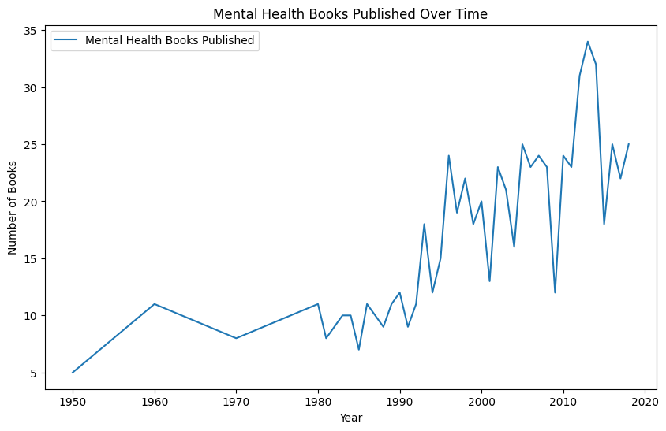

```python
import matplotlib.pyplot as plt

#visualize the number of mental health books over time

plt.figure(figsize=(10, 6))
plt.plot(merged_df['YEAR'], merged_df['num_books'], label='Mental Health Books Published')
plt.xlabel('Year')
plt.ylabel('Number of Books')
plt.title('Mental Health Books Published Over Time')
plt.legend()
plt.show()
```

There are peaks shorlty after 2010 and a drop in some years like 2015.Overall there is a general increase over time.

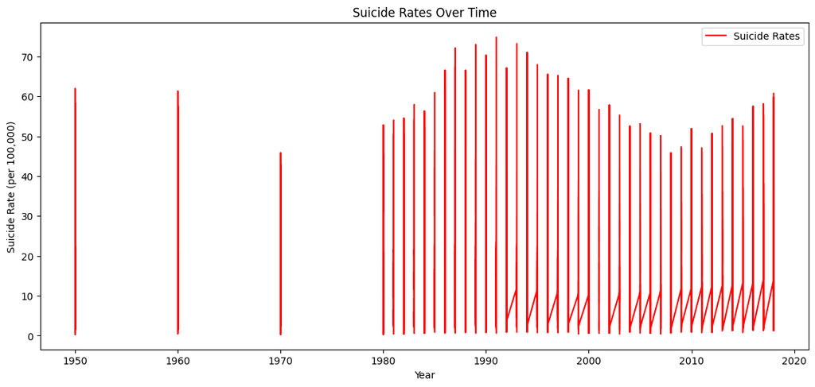

```python
# visualize suicide rates per year
plt.figure(figsize=(12, 6))
plt.plot(merged_df['YEAR'], merged_df['suicide_rate'], label='Suicide Rates', color='red')
plt.xlabel('Year')
plt.ylabel('Suicide Rate (per 100,000)')
plt.title('Suicide Rates Over Time')
plt.legend()
plt.show()
```

The suicide rates are highest in 1990 and relatively low in 2010.

# Analysis

This looks at the relationship between suicide rates over time and the number of mental health-related books published. The goal is to explore whether trends in mental health awareness, as reflected in publications, align with changes in societal suicide rates.

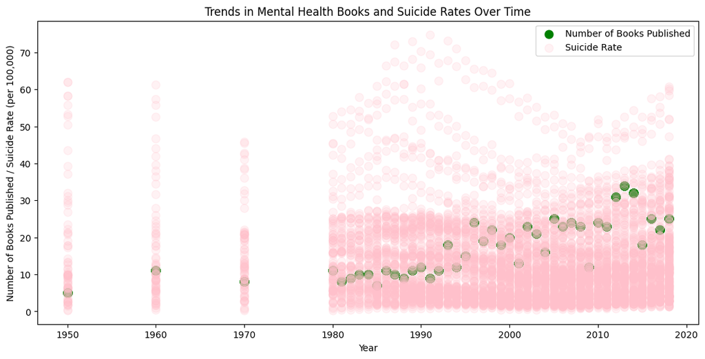

```python
import matplotlib.pyplot as plt
# include data from both previous visualizaiton and sort by year
plt.figure(figsize=(13, 6))

# Scatter plot
plt.scatter(merged_df['YEAR'], merged_df['num_books'], color='green', alpha=1, label='Number of Books Published', s=80)  # Increased size (s=80)
plt.scatter(merged_df['YEAR'], merged_df['suicide_rate'], color='pink', alpha=0.2, label='Suicide Rate', s=80)  # Adjusted transparency for visibility

# Add labels and title
plt.xlabel('Year')
plt.ylabel('Number of Books Published / Suicide Rate (per 100,000)')  # Combined label
plt.title('Trends in Mental Health Books and Suicide Rates Over Time')

# Add legend
plt.legend()

plt.show()
```

Our data is clustered which means that there are specific time period that could benefit from further analysis, like looking at social context. We can however see that in some clusters when the number of books were published was higher (2010), the suicide rates were lower than we have seen. And in places where suicide rates were at its highest (70 (per 100,000) the book publication was lower (around 10 books). High suicide rates with low books published could indicate a time of low awareness about mental health, or perhaps the mental health movement was not as prevalent during that time, and suicide rates were higher because people had fewer resources and support. Showing a need for a push in awareness and mental health resources in that specific period. Low suicide rate with high books published could indicate periods of greater mental health awareness and possibly availability of resources help prevent suicide. This aligns with when there was an increas in mental health awareness campaigns in 21st. This shows the importacnce of continuing to build on the increasing mental health awareness to reduce suicide rates.

# Conclusion

In this project, I analyzed the relationship between the number of mental health books published and suicide rates over time. Using data from various sources, I plotted both variables against each other to observe trends and potential correlations over time. I began by creating scatter plots to visualize the relationship between the two factors, adjusting for visibility with different colors and transparency. I also looked at this over time to help understand the politcal and social context of both of these variables. The project aimed to uncover any significant patterns regarding the availability of mental health resources, represented by the number of books, and how it correlates with changes in suicide rates. The findings provide a foundation for further investigation into the factors influencing mental health awareness and suicide prevention. From here we could do further investigating.We could investigate external factors like media influence or economic conditions.Adding these factors to the analysis could provide deeper insight.